# Criticker Reviews Text Mining Analysis

Chris Selig

2020-04-19

# Summary

My brother and a couple of his friends provide movie reviews on the site [Criticker.com](https://www.criticker.com/). I thought it would be fun to provide them with a text analysis of their movie reviews. What follows is that review.

The code for this analysis can be on my [Github page](https://github.com/chrisselig/movie_review_text_analysis).

You can also find the three reviewers pages here:

1. [Tyler](https://www.criticker.com/profile/Obdurate/)
2. [Zach](https://www.criticker.com/profile/XakkMaster/)
3. [Justin](https://www.criticker.com/profile/TheRealJ_Ro/)

## The Data

The dataset is simple. It is comprised of 3 xml exports for each user and after cleaning, there are only two columns:

1. quote: ghe movie review
2. reviewer: the first name of the reviewer

The following steps were taken to preprocess the data.

First, I only cared about movies that actually had a review so for any movies that just had a score were removed.

Second, the movie reviews were tokenized. Tokenization means taking a review and breaking it out into one word per row. This makes the dataset significantly longer.

Finally, a significant amount of words in the English language are not useful for sentiment analysis or prediction. Some examples are ‘and’ and ‘the’. These words are otherwise known as stop words and have been removed from the dataset.

## Exploratory Analysis

A good place to start with any analysis is with an exploration of the data.

First, a quick look at how many reviews have been created and how many total words have been written for each reviewer.

Review Summary

Summary Statistics for Each Reviewer

| Reviewer | Review Count | Total Word Count | Word Count excl Stop Words | Avg Word Count per Review | Shortest Review | Longest Review | % of Stop Words |
| --- | --- | --- | --- | --- | --- | --- | --- |
| Justin | 1,261 | 85,100 | 29,576 | 68 | 1 | 106 | 65.0% |
| Tyler | 2,092 | 140,954 | 43,729 | 67 | 1 | 107 | 69.0% |
| Zach | 604 | 37,305 | 16,022 | 62 | 1 | 100 | 57.0% |

Second, I will take a look at the most common words from all the reviewers combined.

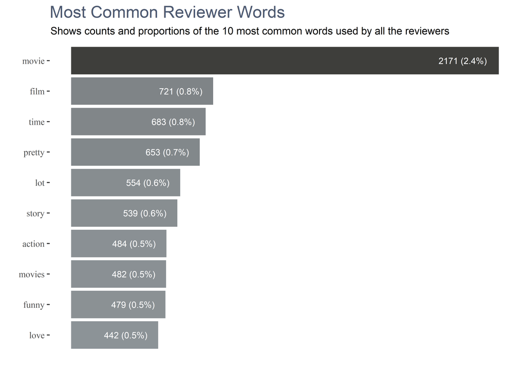

Looking at the image above, the top word used across all three reviewers is ‘movie’, which is not a big surprise. Furthermore, none of the words on the list look out of place for movie reviewers.

After knowing the top ten words, lets look at the top 10 words for each reviewer.

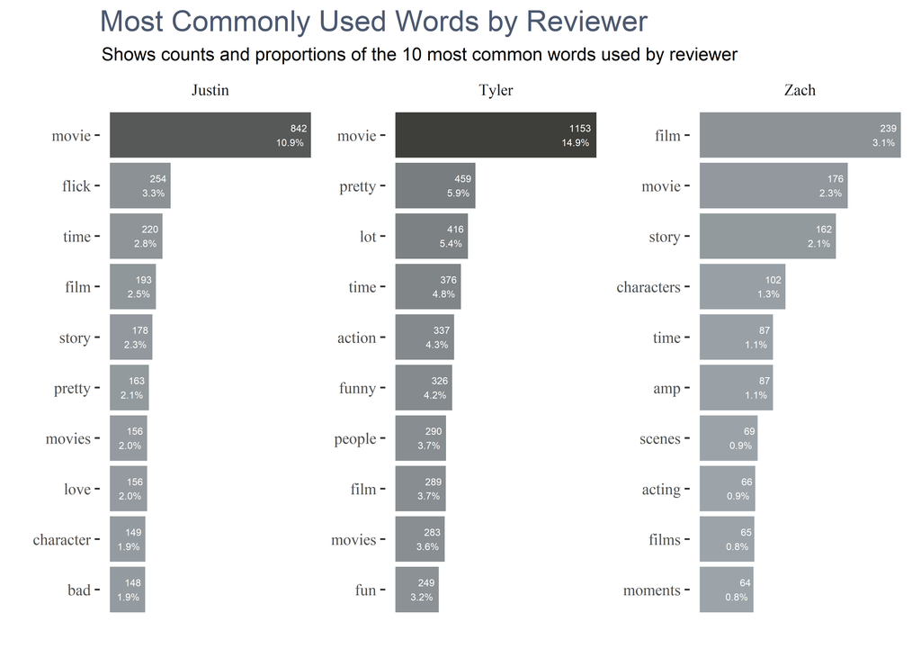

Generally speaking, both Tyler and Justin use some pretty similar words. What is interesting to me is that Zach actually uses ‘film’ more often than ‘movie’, which is less popular between Tyler and Justin. Also, Zach likes to talk about scenes more often than both Tyler or Justin.